# Modelling infectious disease dynamics with R [extras C]

Roel Bakker, PhD

April 2024

## Agenda

1. Models of dynamical systems implemented in R with deSolve
   1. Exponential decay
   2. SIR model
   3. TIME Impact core model
   4. Demo: implementation of TIME impact core model in tbvax
2. Assignments:
   1. complete the assignments so far
   2. experiment with the tbvax model

### 1.1 Exponential Decay

$dy(t)/dt = -k \cdot y(t)$

with $y(t)$ a function of time.

See expdecay-etc.R

### 1.2 SIR model

Differential equations:

$dS/dt = −b\cdot c\cdot \frac{I}{N} \cdot S$

$dI/dt = b\cdot c\cdot \frac{I}{N} \cdot S - \frac{I}{d}$

$dR/dt = \frac{I}{d}$

with $N=S+I+R$

and  
$b$: transmission probability per contact  
$c$: contact rate (the number of contacts per unit time)  
$d$: duration of the infectious period

see SIR_model.R

### 1.3 TIME impact model (core model only: no age groups, MDR, treatment history)

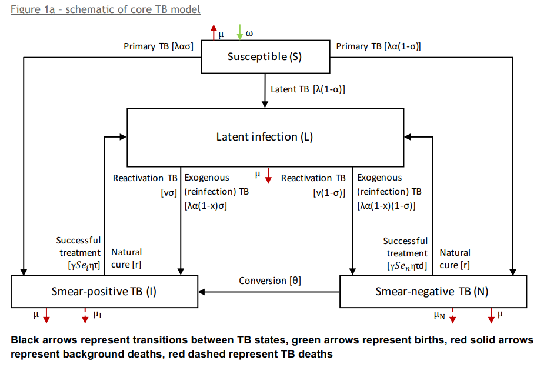

from Tech appendix of BMC Medicine 2016 paper by Houben

see TIME-core.R

use the picture above to define the differential equations in the derivs() function !

experiment with your model

… or peek at the solution: TIME-core-sol.R

### 1.4 Demo: TIME impact model implemented in tbvax

### 2.1 Assignment (originally for week 3) [not for the faint of heart :-)]:

Read the paper by Tom Sumner and Richard White in BMC Infectious Diseases: https://bmcinfectdis.biomedcentral.com/articles/10.1186/s12879-020-05592-5

including the appendix: https://static-content.springer.com/esm/art%3A10.1186%2Fs12879-020-05592-5/MediaObjects/12879_2020_5592_MOESM1_ESM.docx

Implement model 1 in deSolve

Research questions:

- what is the predicted dynamics (i.e. in what time frame would we see an impact) of the impact of TPT on TB disease incidence?
- what is the predicted dynamics of ACF on TB disease incidence?
- which intervention would be cheaper (e.g. costs per incident case averted)?

See also https://roelb54.shinyapps.io/TBvaxdemo/